# Nate Koser

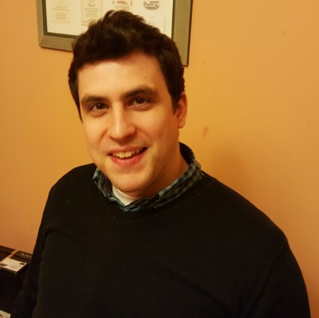

Department of Linguistics, Rutgers University  
18 Seminary Place, New Brunswick NJ  
nate.koser@rutgers.edu  
CV

### About me

Hello, I’m Nate - a linguistics PhD student at Rutgers University. I’m originally from Canton, NY. I received my undergraduate degree from SUNY Binghamton and spent 5 years in South Korea before entering the program here in New Jersey. I am interested in computational phonology. If you have any questions, you’re always welcome to email me.

### Papers

- Koser, Nate and Adam Jardine (to appear). *The complexity of optimizing over strictly local constraints*. Proceedings of PLC 43.
- Koser, Nate, Chris Oakden and Adam Jardine (2019). *Tone association and output locality in non-linear structures.* Supplemental proceedings of AMP 2018. pdf
- Koser, Nate. *Acoustic correlates of creaky voice in Yoruba*. Ms., Rutgers University. pdf
- Koser, Nate. *A constraint definition language and consequences for stress assignment.*. Ms., Rutgers University. pdf

### Presentations

- Koser, Nate (2019). *Creaky voice in Yoruba.* RULing XIV. Rutgers University. slides
- Koser, Nate and Adam Jardine (2019). *The complexity of optimizing over strictly local constraints*. PLC 43. slides
- Koser, Nate and Adam Jardine (2018). *Strictly local patterns are closed under optimization.* NecPhon 2018. slides
- Koser, Nate (2018). *A constraint definition language and consequences for stress assignment.* RULing XIII. Rutgers University. slides
- Koser, Nate, Chris Oakden and Adam Jardine (2018). *Tone association and output locality in non-linear structures.* AMP 2018. abstract poster

### Teaching

- Fall ’18 - Ling201: Intro to Linguistic Theory
- Spring ’19 - Ling201: Intro to Linguistic Theory